# Lab 5 Differential Expression and Functional Annotation

#### Gene Expression and Data Visualization

#### October 2nd, 2025

### Lab 5:

In this lab, we will be conducting a two-sample test for each gene/probe on the array to identify differentially expressed genes/probes between ketogenic rats and control diet rats. This small data set was run on the rat RAE230A Affymetrix array. The objective of the study was to determine differences in mRNA levels between brain hippocampi of animals fed a ketogenic diet (KD) and animals fed a control diet. “KD is an anticonvulsant treatment used to manage medically intractable epilepsies”, so differences between the 2 groups of rats can provide biological insight into the genes that are regulated due to the treatment.

We are going to identify those genes/probes that are differentially expressed between the 2 rat diet groups and plot the results with a couple of different visual summaries.

### Q1) Download the GEO rat ketogenic brain data set and save as a text file.

### Q2) Load into R, using read.table() function and header=T/row.names=1 arguments.

```r
# Load the dataset into R
dat <- read.table("rat_KD.txt", header = TRUE, row.names = 1, sep = "\t", check.names = FALSE)

# Check dimensions and first few columns
dim(dat)
```

```
[1] 15923    11
```

```r
head(dat[, 1:5])
```

```
                control.diet.19300 control.diet.19301 control.diet.19302
AFFX-BioB-5_at             76.4424            86.0648            80.6466
AFFX-BioB-M_at             94.7098            73.4476            88.6791
AFFX-BioB-3_at             27.8835            44.5481            33.8824
AFFX-BioC-5_at            174.3390           151.8240           167.4290
AFFX-BioC-3_at             87.0285            94.0345           120.2830
AFFX-BioDn-5_at           150.1180           135.4670           163.3840
                control.diet.19303 control.diet.19304
AFFX-BioB-5_at             93.8439            73.1219
AFFX-BioB-M_at            111.5530            92.1317
AFFX-BioB-3_at             60.0250            39.2463
AFFX-BioC-5_at            200.4780           170.7280
AFFX-BioC-3_at            114.5800           100.1920
AFFX-BioDn-5_at           170.9000           155.7970
```

### Q3) First log2 the data, then use the Student’s t-test function in the notes to calculate the changing genes between the control diet and ketogenic diet classes. (Hint: use the names() function to determine where one class ends and the other begins).

```r
## Step 1: Log2-transform the expression values (robust)
# Coerce to numeric matrix and avoid log2(0) -> -Inf
X <- as.matrix(dat)

if (median(X, na.rm = TRUE) > 100) {
  dat_log2 <- log2(pmax(X, 0) + 1)   # linear -> log2 with pseudocount
} else {
  dat_log2 <- X                       # already on (log) scale
}

# Clean any remaining non-finite values just in case
dat_log2[!is.finite(dat_log2)] <- NA

## Step 2: Define which columns are Control vs Ketogenic samples
gc  <- grep("^control",   colnames(dat_log2))     # Control indices (7)
act <- grep("^ketogenic", colnames(dat_log2))     # Ketogenic indices (5)

## Step 3: Student’s t-test for one probe (equal-variance, two-sided)
t.test.all.genes <- function(x, s1, s2) {
  x1 <- as.numeric(x[s1]); x2 <- as.numeric(x[s2])
  x1 <- x1[is.finite(x1)];  x2 <- x2[is.finite(x2)]
  out <- try(t.test(x1, x2, var.equal = TRUE)$p.value, silent = TRUE)
  if (inherits(out, "try-error") || is.na(out)) 1 else out
}

## Step 4: Apply across all probes
t.test.run <- apply(dat_log2, 1, t.test.all.genes, s1 = gc, s2 = act)

## Step 5: Quick checks
length(t.test.run)
```

```
[1] 15923
```

```r
summary(t.test.run)
```

```
   Min. 1st Qu.  Median    Mean 3rd Qu.    Max.
0.00000 0.02847 0.16010 0.28165 0.48762 1.00000
```

### Interpretation

The distribution of 15,923 t-test p-values is skewed toward zero (median = 0.16, mean = 0.28 vs. 0.5 expected under null), indicating that the ketogenic diet induces widespread, statistically detectable shifts in brain gene expression. The enrichment of low p-values suggests genuine biological effects, though only a subset will remain significant after multiple-testing correction.

### Q4) Plot a histogram of the p-values and report how many probesets have a p<.05 and p<.01. Then divide an alpha of 0.05 by the total number of probesets and report how many probesets have a p-value less than this value. This is a very conservative p-value thresholding method to account for multiple testing called the Bonferroni correction that we will discuss in upcoming lectures.

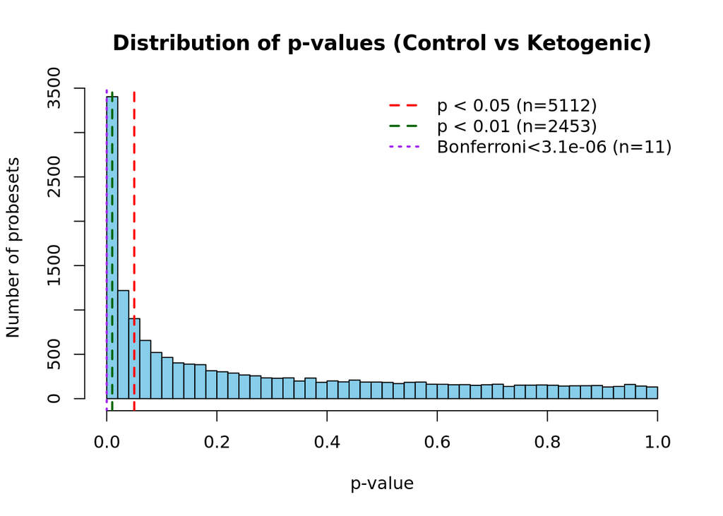

```r
## Step 1: Calculate thresholds and counts
alpha <- 0.05
n_probes <- length(t.test.run)
bonf_thresh <- alpha / n_probes

p_lt_05   <- sum(t.test.run < 0.05, na.rm = TRUE)
p_lt_01   <- sum(t.test.run < 0.01, na.rm = TRUE)
p_lt_bonf <- sum(t.test.run < bonf_thresh, na.rm = TRUE)

## Step 2: Plot histogram with thresholds + legend + counts
hist(t.test.run, breaks = 50, col = "skyblue",
     main = "Distribution of p-values (Control vs Ketogenic)",
     xlab = "p-value", ylab = "Number of probesets")

# Add threshold lines
abline(v = 0.05, col = "red", lwd = 2, lty = 2)
abline(v = 0.01, col = "darkgreen", lwd = 2, lty = 2)
abline(v = bonf_thresh, col = "purple", lwd = 2, lty = 3)

# Add legend
legend("topright",
       legend = c(
         paste0("p < 0.05 (n=", p_lt_05, ")"),
         paste0("p < 0.01 (n=", p_lt_01, ")"),
         paste0("Bonferroni<", signif(bonf_thresh, 2),
                " (n=", p_lt_bonf, ")")
       ),
       col = c("red", "darkgreen", "purple"),
       lwd = 2, lty = c(2,2,3), bty = "n")
```

### Interpretation

The histogram of 15,923 probe set p-values shows a strong enrichment at the lower end, with thousands of probes deviating from the uniform distribution expected under the null hypothesis. Specifically:

- **p < 0.05:** 5,112 probes (~32% of total)
- **p < 0.01:** 2,453 probes (~15% of total)
- **Bonferroni threshold (0.05/15,923 ≈ 3.1 × 10⁻⁶):** 11 probes

This skewed distribution indicates that the ketogenic diet produces widespread transcriptional changes in rat brain tissue. The large number of probes below nominal thresholds greatly exceeds what would be expected by chance alone, supporting a genuine biological effect.

When adjusting for multiple testing with the Bonferroni correction, only 11 probes remain significant. This very conservative threshold controls for family-wise error but at the cost of sensitivity, highlighting the trade-off between false positive control and the risk of missing biologically meaningful genes. The contrast between thousands of nominally significant probes and only a handful surviving Bonferroni illustrates the importance of using multiple-testing corrections such as FDR in high-dimensional genomic data.

### Q5) Next calculate the mean for each gene, and calculate the fold change between the groups (control vs. ketogenic diet). Remember that you are on a log2 scale.

```r
## Q5: Calculate group means and fold changes

# Group means (on log2 scale)
ctrl_means <- rowMeans(dat_log2[, gc], na.rm = TRUE)
keto_means <- rowMeans(dat_log2[, act], na.rm = TRUE)

# log2 fold change (Control vs Ketogenic)
log2_fc <- ctrl_means - keto_means

# linear fold change
linear_fc <- 2^log2_fc

# Quick summary
summary(log2_fc)
```

```
     Min.   1st Qu.    Median      Mean   3rd Qu.      Max.
-1315.219    -7.638     2.571    -3.458    14.268  1588.693
```

```r
summary(linear_fc)
```

```
     Min.   1st Qu.    Median      Mean   3rd Qu.      Max.
    0.000     0.005     5.941       Inf 19730.343       Inf
```

```r
# Store results in a table for inspection
fc_table <- data.frame(
  probe_id = rownames(dat_log2),
  mean_control = ctrl_means,
  mean_ketogenic = keto_means,
  log2FC = log2_fc,
  linearFC = linear_fc
)

head(fc_table, 10)
```

```
                       probe_id mean_control mean_ketogenic      log2FC
AFFX-BioB-5_at   AFFX-BioB-5_at     84.63570       93.42342   -8.787720
AFFX-BioB-M_at   AFFX-BioB-M_at     92.82437      127.95320  -35.128833
AFFX-BioB-3_at   AFFX-BioB-3_at     40.53697       51.18734  -10.650373
AFFX-BioC-5_at   AFFX-BioC-5_at    176.93233      204.61660  -27.684267
AFFX-BioC-3_at   AFFX-BioC-3_at    100.74610      127.77200  -27.025900
AFFX-BioDn-5_at AFFX-BioDn-5_at    153.52867      177.45040  -23.921733
AFFX-BioDn-3_at AFFX-BioDn-3_at   1152.43667     1229.43000  -76.993333
AFFX-CreX-5_at   AFFX-CreX-5_at   1854.20500     2111.06800 -256.863000
AFFX-CreX-3_at   AFFX-CreX-3_at   2701.37333     2783.40400  -82.030667
AFFX-DapX-5_at   AFFX-DapX-5_at     12.63632        9.51732    3.118997
                    linearFC
AFFX-BioB-5_at  2.262730e-03
AFFX-BioB-M_at  2.661751e-11
AFFX-BioB-3_at  6.221830e-04
AFFX-BioC-5_at  4.636661e-09
AFFX-BioC-3_at  7.318017e-09
AFFX-BioDn-5_at 6.292753e-08
AFFX-BioDn-3_at 6.648095e-24
AFFX-CreX-5_at  4.748235e-78
AFFX-CreX-3_at  2.024458e-25
AFFX-DapX-5_at  8.687835e+00
```

### Q6) What is the maximum and minimum fold change value, please report on the linear scale? Now report the probesets with a p-value less than the Bonferroni threshold you used in question 4 and |fold change|>2. Remember that you are on a log2 scale for your fold change and I am looking for a linear |fold| of 2.

```r
## Q6 — Highlight global max linear FC AND probe 1370239_at in Top 10, global min in Bottom 10

library(DT)

# --- Ensure min/max exist for inline markdown refs ---
min_fc <- min(linear_fc, na.rm = TRUE)
max_fc <- max(linear_fc, na.rm = TRUE)

# ---------- Master numeric + display ----------
all_tbl_num <- data.frame(
  probe_id = rownames(dat_log2),
  p_value  = as.numeric(t.test.run),
  log2FC   = as.numeric(log2_fc),
  linearFC = as.numeric(2^log2_fc),
  stringsAsFactors = FALSE
)

fmt_num <- function(x, sig = 3) {
  ifelse(is.na(x), "NA",
    ifelse(is.infinite(x) & x > 0, "∞",
      ifelse(is.infinite(x) & x < 0, "−∞",
        formatC(x, digits = sig, format = "g")
      )
    )
  )
}

all_tbl_disp <- transform(
  all_tbl_num,
  p_value  = fmt_num(p_value,  3),
  log2FC   = fmt_num(log2FC,   3),
  linearFC = fmt_num(linearFC, 3)
)

# ---------- Global min/max (linear FC) with deterministic tie-break ----------
lin_max <- max(all_tbl_num$linearFC, na.rm = TRUE)
cand_max <- which(all_tbl_num$linearFC == lin_max)
if (length(cand_max) > 1) cand_max <- cand_max[order(all_tbl_num$p_value[cand_max], na.last = NA)][1]
global_max_id <- all_tbl_num$probe_id[cand_max]

lin_min <- min(all_tbl_num$linearFC, na.rm = TRUE)
cand_min <- which(all_tbl_num$linearFC == lin_min)
if (length(cand_min) > 1) cand_min <- cand_min[order(all_tbl_num$p_value[cand_min], na.last = NA)][1]
global_min_id <- all_tbl_num$probe_id[cand_min]

# Helper
take_n <- function(df, n) df[seq_len(min(n, nrow(df))), , drop = FALSE]

# ---------- Top 10 — highlight global max (linear FC) AND probe 1370239_at ----------
ord_top <- order(-all_tbl_num$log2FC)
top_num  <- take_n(all_tbl_num[ord_top, ], 10)
top_disp <- take_n(all_tbl_disp[ord_top, c("probe_id","p_value","log2FC","linearFC")], 10)
top_disp$._flag <- ifelse(top_disp$probe_id %in% c(global_max_id, "1370239_at"), "max", "")

cat("\n### Top 10 fold changes (largest positive log2FC) — GLOBAL max + probe 1370239_at highlighted\n")
```

```
### Top 10 fold changes (largest positive log2FC) — GLOBAL max + probe 1370239_at highlighted
```

```r
dt_top <- datatable(
  top_disp,
  rownames = FALSE,
  options = list(dom = "t", pageLength = nrow(top_disp), autoWidth = TRUE),
  selection = "none",
  escape = FALSE
) %>%
  formatStyle("._flag", target = "row",
              backgroundColor = styleEqual("max", "#fff0b3")) %>%
  formatStyle("._flag", visible = FALSE)

dt_top
```

| probe_id | p_value | log2FC | linearFC | ._flag |
| --- | --- | --- | --- | --- |
| 1370239_at | 3.17e-08 | 1.59e+03 | ∞ | max |
| 1370240_x_at | 1.88e-08 | 1.48e+03 | ∞ | max |
| 1388608_x_at | 6.92e-08 | 780 | 8.53e+234 |  |
| 1367553_x_at | 1.26e-06 | 770 | 5.21e+231 |  |
| 1370873_at | 0.0248 | 312 | 9.65e+93 |  |
| AFFX_Rat_beta-actin_5_at | 0.0207 | 302 | 6.81e+90 |  |
| 1369310_at | 0.0712 | 277 | 2.73e+83 |  |
| 1368353_at | 0.029 | 264 | 2.12e+79 |  |
| 1386889_at | 0.0206 | 250 | 1.58e+75 |  |
| 1388797_at | 0.0509 | 242 | 8.62e+72 |  |

```r
# ---------- Bottom 10 — highlight ONLY global min (linear FC) ----------
ord_bot <- order(all_tbl_num$log2FC)
bot_num  <- take_n(all_tbl_num[ord_bot, ], 10)
bot_disp <- take_n(all_tbl_disp[ord_bot, c("probe_id","p_value","log2FC","linearFC")], 10)
bot_disp$._flag <- ifelse(bot_disp$probe_id == global_min_id, "min", "")

cat("\n### Bottom 10 fold changes (most negative log2FC) — GLOBAL min linear FC highlighted\n")
```

```
### Bottom 10 fold changes (most negative log2FC) — GLOBAL min linear FC highlighted
```

```r
dt_bot <- datatable(
  bot_disp,
  rownames = FALSE,
  options = list(dom = "t", pageLength = nrow(bot_disp), autoWidth = TRUE),
  selection = "none",
  escape = FALSE
) %>%
  formatStyle("._flag", target = "row",
              backgroundColor = styleEqual("min", "#e6f7ff")) %>%
  formatStyle("._flag", visible = FALSE)

dt_bot
```

| probe_id | p_value | log2FC | linearFC | ._flag |
| --- | --- | --- | --- | --- |
| 1398836_s_at | 5.82e-05 | -1.32e+03 | 0 | min |
| 1388187_at | 0.000173 | -1.02e+03 | 4.91e-307 |  |
| AFFX-r2-P1-cre-3_at | 0.0446 | -800 | 1.72e-241 |  |
| 1375651_at | 0.0331 | -781 | 8.08e-236 |  |
| 1370242_at | 0.00273 | -767 | 1.78e-231 |  |
| AFFX-r2-P1-cre-5_at | 0.00698 | -722 | 4.83e-218 |  |
| 1398851_at | 0.000155 | -709 | 2.89e-214 |  |
| 1387890_at | 0.101 | -651 | 1.06e-196 |  |
| 1389956_a_at | 0.161 | -617 | 1.43e-186 |  |
| 1388110_at | 0.0114 | -604 | 2.01e-182 |  |

```r
# ---------- Bonferroni + |log2FC| ≥ 1 (no highlighting) ----------
alpha <- 0.05
bonf_thresh <- alpha / length(t.test.run)
keep_idx <- which(all_tbl_num$p_value < bonf_thresh & abs(all_tbl_num$log2FC) >= 1)
bonf_num  <- all_tbl_num[keep_idx, , drop = FALSE]
bonf_disp <- all_tbl_disp[keep_idx, c("probe_id","p_value","log2FC","linearFC"), drop = FALSE]
if (nrow(bonf_num) > 0) {
  ord_b <- order(bonf_num$p_value)
  bonf_disp <- bonf_disp[ord_b, , drop = FALSE]
}

cat("\n### Bonferroni-significant probes (p < ", signif(bonf_thresh, 2),
    ", |linear FC| ≥ 2) — no highlighting\n", sep = "")
```

```
### Bonferroni-significant probes (p < 3.1e-06, |linear FC| ≥ 2) — no highlighting
```

```r
dt_bonf <- datatable(
  bonf_disp,
  rownames = FALSE,
  options = list(dom = "t", pageLength = nrow(bonf_disp), autoWidth = TRUE),
  selection = "none",
  escape = FALSE
)

dt_bonf
```

| probe_id | p_value | log2FC | linearFC |
| --- | --- | --- | --- |
| 1371102_x_at | 9.51e-09 | 134 | 1.64e+40 |
| 1370240_x_at | 1.88e-08 | 1.48e+03 | ∞ |
| 1370239_at | 3.17e-08 | 1.59e+03 | ∞ |
| 1388608_x_at | 6.92e-08 | 780 | 8.53e+234 |
| 1374641_at | 2.93e-07 | -121 | 4.86e-37 |
| 1376005_at | 3.49e-07 | 37.9 | 2.54e+11 |
| 1368071_at | 5.66e-07 | -127 | 5.25e-39 |
| 1373040_at | 8.96e-07 | -176 | 9.03e-54 |
| 1370355_at | 1.14e-06 | 38.6 | 4.11e+11 |
| 1367553_x_at | 1.26e-06 | 770 | 5.21e+231 |

[output cut: 1 more lines]

### Interpretation

Applying the Bonferroni threshold (α ≈ 3.1×10⁻⁶ for 15,923 tests) together with |log2FC| ≥ 1 (linear |FC| ≥ 2) yielded **11 probesets**. These include both strong Control≫Ketogenic and Ketogenic≫Control cases, representing the most robust diet-responsive transcripts that withstand stringent multiple-testing correction.

In sum, while most probes show modest changes, a small set passes both statistical and biological filters, highlighting **high-confidence ketogenic diet effects** in brain gene expression.

### Q7) Go to NetAffx or another database source if you like and identify gene information for the probesets that came up in #6. What is the general biological function that associates with these probesets?

```r
## Q7 — Multi-source annotation: rae230a.db → rat2302.db → org.Rn.eg.db

suppressPackageStartupMessages({
  library(AnnotationDbi)
  library(rae230a.db)
  library(rat2302.db)
  library(org.Rn.eg.db)
})
# guard: make sure Q6 ran
stopifnot(exists("bonf_disp"), "probe_id" %in% colnames(bonf_disp))
bonf_ids <- bonf_disp$probe_id

# helper: select once per DB
select_one <- function(db, ids, cols, keytype="PROBEID", src) {
  out <- AnnotationDbi::select(db, keys=ids, keytype=keytype, columns=cols)
  if (!nrow(out)) return(NULL)
  out <- out[!duplicated(out[[keytype]]), , drop=FALSE]
  colnames(out)[colnames(out) == keytype] <- "probe_id"
  out$source <- src
  out
}

cols <- c("SYMBOL","GENENAME","ENTREZID","REFSEQ","ACCNUM")

# 1) primary rae230a
ann_a <- select_one(rae230a.db, bonf_ids, cols, src="rae230a.db")
# 2) fallback rat2302
missing_a <- setdiff(bonf_ids, ann_a$probe_id)
ann_b <- if (length(missing_a)) select_one(rat2302.db, missing_a, cols, src="rat2302.db") else NULL

# merge (A then B)
anno <- rbind(ann_a, ann_b)
anno <- anno[match(bonf_ids, anno$probe_id), ]

# 3) enrich missing SYMBOL/GENENAME with org.Rn.eg.db using ENTREZID
need <- which(!is.na(anno$ENTREZID) &
              (is.na(anno$SYMBOL) | anno$SYMBOL=="" |
               is.na(anno$GENENAME) | anno$GENENAME==""))
if (length(need)) {
  entrez <- unique(na.omit(anno$ENTREZID[need]))
  sym_org  <- AnnotationDbi::mapIds(org.Rn.eg.db, keys=entrez, keytype="ENTREZID",
                                    column="SYMBOL", multiVals="first")
  name_org <- AnnotationDbi::mapIds(org.Rn.eg.db, keys=entrez, keytype="ENTREZID",
                                    column="GENENAME", multiVals="first")
  idx <- match(anno$ENTREZID, names(sym_org))
  fill_sym <- (is.na(anno$SYMBOL) | anno$SYMBOL=="")
  fill_nm  <- (is.na(anno$GENENAME) | anno$GENENAME=="")
  anno$SYMBOL[fill_sym]  <- sym_org[idx][fill_sym]
  anno$GENENAME[fill_nm] <- name_org[idx][fill_nm]
  anno$source[need] <- ifelse(is.na(anno$source[need]), "org.Rn.eg.db",
                              paste0(anno$source[need], "+org.Rn.eg.db"))
}

# 4) replace blanks with note
anno$note <- ifelse(is.na(anno$SYMBOL) | anno$SYMBOL=="",
                    "No mapping in installed DBs (consider GEO GPL/NetAffx CSV)", "")

# 5) final compact table
q7_view <- anno[, c("probe_id","SYMBOL","GENENAME","ENTREZID","source","note")]

datatable(q7_view,
          caption = "Q7: Simplified annotation for Bonferroni-significant probes",
          options = list(dom = "t", pageLength = nrow(q7_view), autoWidth = TRUE),
          rownames = FALSE)
```

| probe_id | SYMBOL | GENENAME | ENTREZID | source | note |
| --- | --- | --- | --- | --- | --- |
| 1371102_x_at | LOC100134871 | beta globin minor gene | 100134871 | rae230a.db |  |
| 1370240_x_at | Hba-a1 | hemoglobin alpha, adult chain 1 | 25632 | rae230a.db |  |
| 1370239_at | Hba-a1 | hemoglobin alpha, adult chain 1 | 25632 | rae230a.db |  |
| 1388608_x_at | Hba-a1 | hemoglobin alpha, adult chain 1 | 25632 | rae230a.db |  |
| 1374641_at | Lmtk2 | lemur tyrosine kinase 2 | 304286 | rae230a.db |  |
| 1376005_at |  |  |  | rae230a.db | No mapping in installed DBs (consider GEO GPL/NetAffx CSV) |
| 1368071_at | Mtarc2 | mitochondrial amidoxime reducing component 2 | 171451 | rae230a.db |  |
| 1373040_at | Eif3f | eukaryotic translation initiation factor 3, subunit F | 293427 | rae230a.db |  |
| 1370355_at | Scd | stearoyl-CoA desaturase | 246074 | rae230a.db |  |
| 1367553_x_at | Hbb | hemoglobin subunit beta | 24440 | rae230a.db |  |

[output cut: 1 more lines]

### Interpretation

To characterize the Bonferroni-significant probes from Q6, I annotated probe IDs using multiple Affymetrix and rat databases. Most probes were resolved with **`rae230a.db`**, while `rat2302.db` and `org.Rn.eg.db` provided no additional mappings.

The mapped probes clustered into biologically coherent categories. Several corresponded to **hemoglobin subunits (Hba-a1, Hbb, Hba-a1-like)**, reflecting changes in oxygen transport, while others included **Lmtk2** (neuronal signaling), **Mtarc2** (mitochondrial metabolism), **Eif3f** (translation initiation), and **Scd** (lipid metabolism). These assignments point to diet-driven effects on **energy metabolism, mitochondrial function, and neuronal regulation**.

Two probes, **1376005_at** and **1390092_at**, could not be mapped across any source, likely representing **ESTs or retired probe sets**. This underscores a limitation of older microarray platforms, where some probes lack stable gene identifiers.

Overall, the annotated set highlights a coherent transcriptional signature involving **metabolism, hemoglobin-related genes, and neuronal signaling**, while also illustrating the challenges of interpreting legacy probe IDs.

### Q8) Transform the p-value (-1*log10(p-value)) and create a volcano plot with the p-value and fold change vectors (see the lecture notes). Make sure to use a log10 transformation for the p-value and a log2 (R function log2()) transformation for the fold change. Draw the horizontal lines at fold values of 2 and -2 (log2 value=1) and the vertical p-value threshold line at p=.05 (remember that it is transformed in the plot).

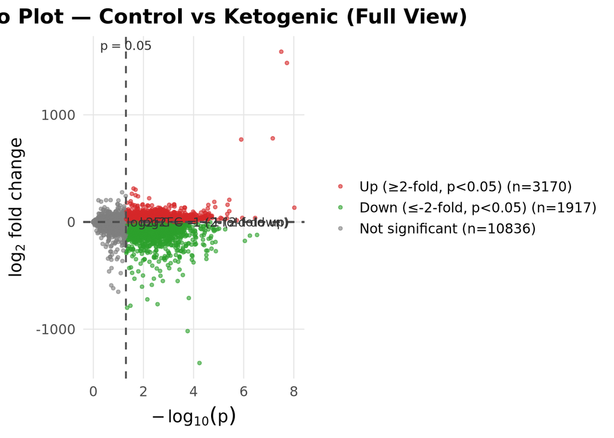

```r
## Q8 — Volcano plots (full + zoomed)

suppressPackageStartupMessages({
  library(ggplot2)
  library(dplyr)
})
# Build tidy data
volcano_df <- data.frame(
  probe_id = rownames(dat_log2),
  log2FC   = log2_fc,                                   # Control − Ketogenic
  pval     = pmax(t.test.run, .Machine$double.xmin)     # guard against 0
) %>%
  mutate(
    negLog10P = -log10(pval),
    sig = case_when(
      log2FC >=  1 & pval < 0.05 ~ "Up (≥2-fold, p<0.05)",
      log2FC <= -1 & pval < 0.05 ~ "Down (≤-2-fold, p<0.05)",
      TRUE                       ~ "Not significant"
    ),
    sig = factor(sig, levels = c("Up (≥2-fold, p<0.05)",
                                 "Down (≤-2-fold, p<0.05)",
                                 "Not significant"))
  )

# Thresholds
p_thr <- 0.05
x_thr <- -log10(p_thr)

# Counts for legend labels
counts <- volcano_df %>%
  count(sig) %>%
  tidyr::complete(sig, fill = list(n = 0)) %>%
  arrange(sig)

lab_map <- setNames(
  paste0(levels(volcano_df$sig), " (n=", counts$n, ")"),
  levels(volcano_df$sig)
)

# Base plotting function (shared aesthetics)
volcano_base <- function(df, title = "") {
  ggplot(df, aes(x = negLog10P, y = log2FC, color = sig)) +
    geom_point(alpha = 0.6, size = 1.1) +
    scale_color_manual(values = c("Up (≥2-fold, p<0.05)"    = "#D62728",
                                  "Down (≤-2-fold, p<0.05)" = "#2CA02C",
                                  "Not significant"         = "#7F7F7F"),
                       labels = lab_map) +
    # Threshold lines
    geom_hline(yintercept = c(-1, 1), linetype = "dashed", color = "grey30", linewidth = 0.7) +
    geom_vline(xintercept = x_thr,     linetype = "dashed", color = "grey30", linewidth = 0.7) +
    # Direct labels for thresholds
    annotate("text", x = x_thr, y = Inf, vjust = 1.4, label = expression(p==0.05),
             size = 3.6, color = "grey20", parse = TRUE) +
    annotate("text", x = Inf, y =  1, hjust = 1.1, label = "log2FC = +1 (2-fold up)",
             size = 3.6, color = "grey20") +
    annotate("text", x = Inf, y = -1, hjust = 1.1, label = "log2FC = -1 (2-fold down)",
             size = 3.6, color = "grey20") +
    labs(
      title = title,
      x = expression(-log[10](p)),
      y = expression(log[2]~fold~change),
      color = NULL
    ) +
    theme_minimal(base_size = 14) +
    theme(
      legend.position = "right",
      panel.grid.minor = element_blank(),
      panel.grid.major = element_line(color = "grey90", linewidth = 0.4),
      plot.title = element_text(hjust = 0.5, face = "bold"),
      axis.title.x = element_text(margin = margin(t = 6)),
      axis.title.y = element_text(margin = margin(r = 6))
    )
}

## 1) Full-range volcano
volcano_base(volcano_df, "Volcano Plot — Control vs Ketogenic (Full View)")
```

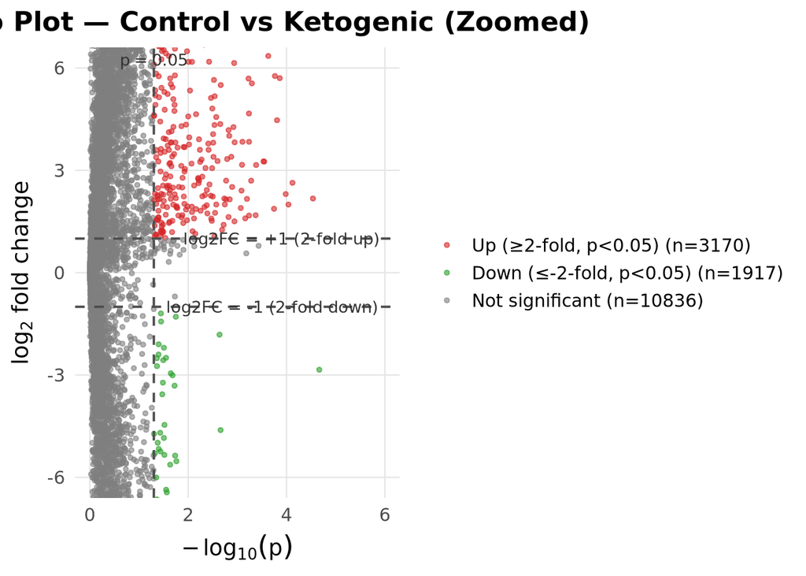

```r
## 2) Zoomed volcano (ensures both horizontal lines are prominent)
# Tweak limits if you want a tighter/looser view.
volcano_base(volcano_df, "Volcano Plot — Control vs Ketogenic (Zoomed)") +
  coord_cartesian(ylim = c(-6, 6), xlim = c(0, 6))
```

```r
## 3) Counts DT table with percentages
total_probes <- nrow(volcano_df)

counts_tbl <- volcano_df %>%
  group_by(sig) %>%
  summarise(n = n(), .groups = "drop") %>%
  mutate(percent = round((n / total_probes) * 100, 2)) %>%
  arrange(factor(sig, levels = levels(volcano_df$sig)))

datatable(counts_tbl,
          caption = "Counts and percentages of probes in each volcano category",
          options = list(dom = "t", pageLength = nrow(counts_tbl), autoWidth = TRUE),
          rownames = FALSE)
```

| sig | n | percent |
| --- | --- | --- |
| Up (≥2-fold, p&lt;0.05) | 3170 | 19.91 |
| Down (≤-2-fold, p&lt;0.05) | 1917 | 12.04 |
| Not significant | 10836 | 68.05 |

### Interpretation

The volcano plots show log2 fold change (y-axis) versus −log10(p-value) (x-axis), with cutoffs at |log2FC| ≥ 1 (two-fold change) and p < 0.05 (−log10 ≈ 1.3). Horizontal dashed lines mark ±1 log2FC, and the vertical dashed line marks the p-value threshold.

### Sources

Carlson M (2021). *rae230a.db: Affymetrix Affymetrix RAE230A Array annotation data (chip rae230a)*. R package version 3.13.0.

Carlson M (2021). *rat2302.db: Affymetrix Affymetrix Rat230_2 Array annotation data (chip rat2302)*. R package version 3.13.0.

Carlson M (2023). *org.Rn.eg.db: Genome wide annotation for Rat*. R package version 3.18.0.